# SNP FILTERING

This filtering scheme follows the FS6 scheme of SJO’Leary but stops the alternate paring of genotypes and missing individuals with missing data at the 70% / 70% step.

## Filtering to yield more loci than FS6

### Step 1: Filter LQ loci

Remove SNPs with quality score < 20, minimum depth per genotype < 5, minimum mean depth < 15.  
This chunk can take some time because it is filtering out the full data set. Adding maf 0.2 here results in ~1000 SNPs, trying to add it later.

### Step 2: Missing data indvidiuals/loci

The max-missing option excludes sites based on the proportion of missing data where 0 is completely missing and 1 is not missing at all.

#### 2a: Retain loci with genotype call rate > 50% and flag individuals with missing data.

#### 2b: Identify individuals with > 90% missing data.

Everything to the right of the blue line will be eliminated.

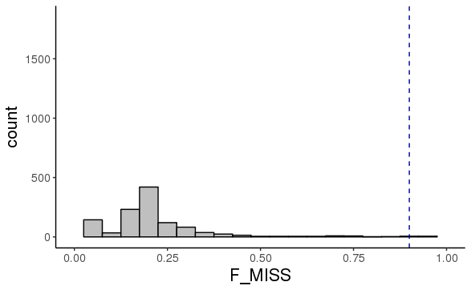

Remove flagged individuals, adding maf 0.2 here results in 0 SNPs, trying later.

### Step 3: Info flag filtering

#### Allele balance

AB: Allele balance at heterozygous sites: a number between 0 and 1 representing the ratio of reads showing the reference allele to all reads, considering only reads from individuals called as heterozygous

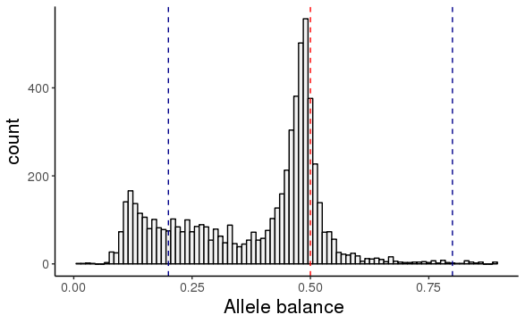

Filter contigs with SNP calls with AB > 0.2, AB > 0.8; retain loci very close to 0 (retain loci that are fixed variants). Remove genotypes if the quality sum of the reference or alternate allele was 0.

#### replot to make sure the changes were effective

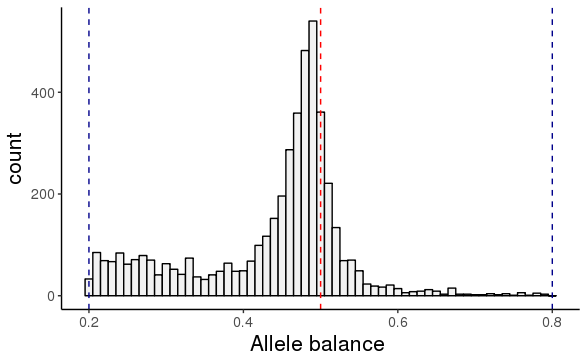

#### Quality/depth ratio

Compare quality/depth.

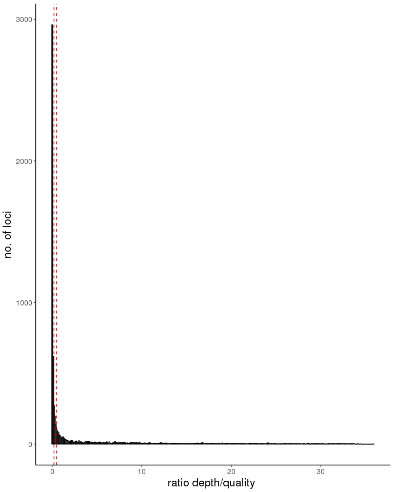

Remove loci with quality/depth ratio < 0.2

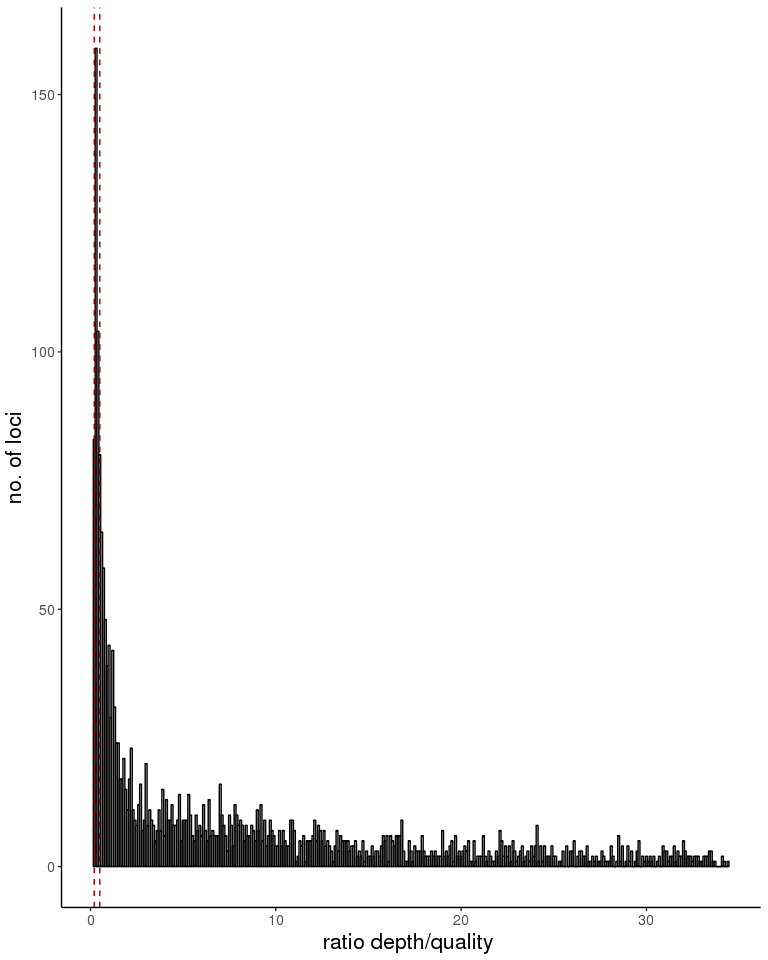

Based on the above graph, I was going to re-do the cutoff at 0.5 but the y-axis shows that the peak went down from 3000 to 150 so even though there is still a peak, it is clearly very zoomed in.

#### ratio mapping quality

Remove loci based on ratio of mapping quality for reference and alternate allele, i.e. sites that have a high discrepancy between the mapping qualities of two alleles. Skipping this step because vcf tools takes more than the red circles.

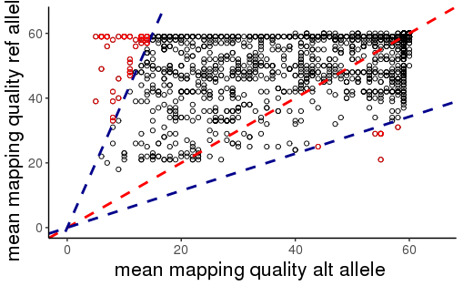

Filter loci with mapping quality ratio < 0.25 and > 1.75.